# kerntools: R tools for kernel methods

Elies Ramon

## Purpose

**kerntools** provides R tools for working with a family of Machine Learning methods called kernel methods. This package implements several kernel functions for treating nonnegative and real vectors, real matrices, categorical and ordinal variables, sets, and strings. Several tools for studying the resulting kernel matrix or to compare two kernel matrices are available. These diagnostic tools may be used to infer the kernel(s) matrix(ces) suitability in model training. `kerntools` also provides functions for extracting the feature importance of Support Vector Machines (SVMs) or displaying customizable kernel Principal Components Analysis (PCA) plots. For convenience, widespread model’s performance measures and feature importance visualization are available for the user.

## Loading

Once the package is installed, it can be loaded anytime typing:

```r
library(kerntools)
```

## Package Overview

In this section several examples will be used to illustrate a typical workflow of `kerntools`.

### A simple example

Let’s suppose we are working with the well known [iris dataset](https://en.wikipedia.org/wiki/Iris_flower_data_set). This dataset contains sepal and petal measurements for *N = 150* iris flowers. These flowers belong to three different species: *Iris setosa*, *Iris versicolor*, and *Iris virginica*. There are *D = 4* numeric variables (also called “features”) that are measured: `Sepal.Length`, `Sepal.Width`, `Petal.Length` and `Petal.Width`.

We first standardize these four variables so they have mean 0 and standard deviation 1. This places them on a common ground. Then, we compute our first kernel: the linear kernel.

```r
iris_std <- scale(iris[,c( "Sepal.Length","Sepal.Width","Petal.Length", "Petal.Width")])
KL <- Linear(iris_std)
dim(KL)
```

```
#> [1] 150 150
```

```r
class(KL)
```

```
#> [1] "matrix" "array"
```

The linear kernel is simply the pairwise inner product between all *N* samples (in our case: flower measurements). The result is “stored” on a matrix (the kernel matrix) that has dimensions *NxN*. Furthermore, it is always symmetric and positive semi-definite (PSD). To check the kernel between two samples (for instance, 32 and 106), we can type either `KL[32,106]` or `KL[106,32]`. It should be noted that kernel matrices generated by `kerntools` have class “matrix”, “array”. In fact, to keep things simple, no function in this package requires any special classes/objects not present in base R.

Next, we examine this kernel matrix further. Although it is not excessively large, it is large enough to make simply typing `KL` in R unpractical. Instead, we may summarize its values using a histogram:

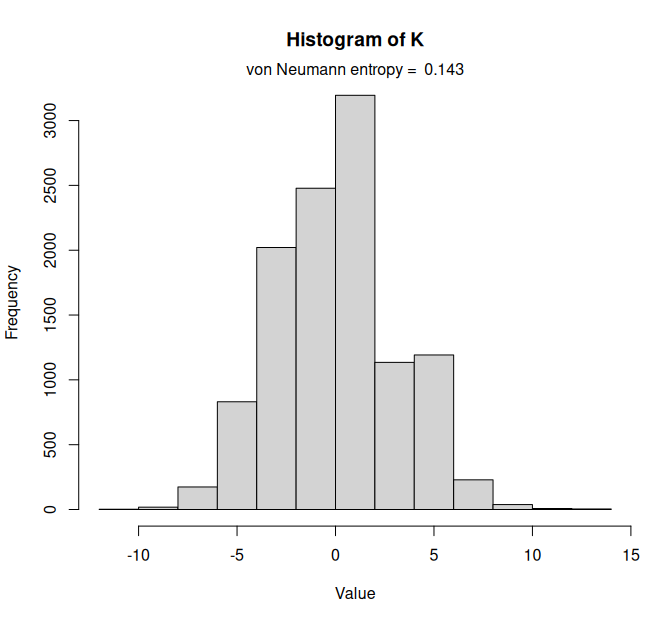

```r
histK(KL, vn = TRUE)
```

This “almost-gaussian” shape is due to the features’ scaling. Further parameters, including color, can be passed to `histK()` (for more info, check the documentation of `graphics::hist()`). The von Neumann entropy shown here is optional (in fact, this value can be computed separately doing `vonNeumann(KL)`). Entropy values close to 0 indicate that all kernel matrix elements are very similar, while values close to 1 indicate a high variability.

Another possibility is to visualize the whole kernel matrix with a heatmap:

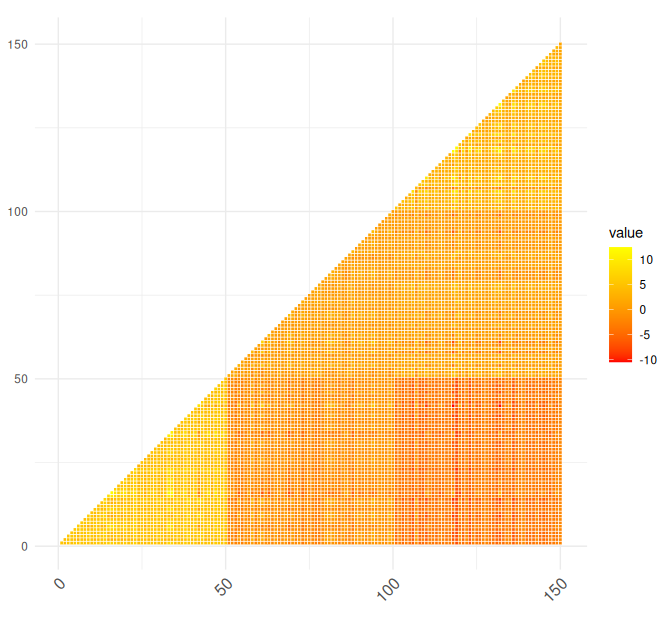

```r
heatK(KL,cos.norm = FALSE)
```

Here, yellow denotes a high similarity between the samples, while red denotes that the similarity is low (the colour palette is customizable via the parameter `color`). At a glance we see that the first 50 samples (*I. setosa*) have a higher intra-group similarity. Also, they are very different from the samples 101-150 (which correspond to *I. virginica*). Instead, *I. versicolor* is kind of intermediate between these two groups.

To confirm our intuitions about the (dis)similarity among the three species, we may proceed to a widespread ordination method: the Principal Components Analysis (PCA). PCAs can be computed from kernel matrices very easily. In fact, using kernel matrices *expands* what a PCA can do, but this will be discussed in further sections. To display a beautiful PCA plot that colors the samples by species, we do:

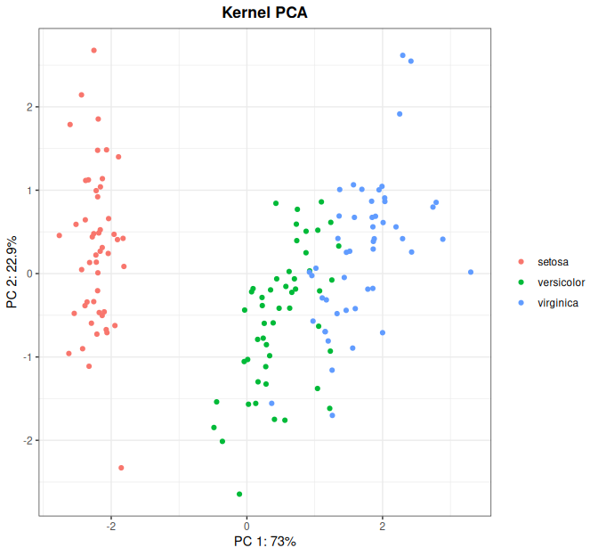

```r
iris_species <- factor(iris$Species)
kpca <- kPCA(KL,plot = 1:2,y = iris_species)
kpca$plot
```

Indeed, we can see that *I. setosa* and *I. virginica* are the most different groups, while *I. versicolor* and *I.virginica* are very close. The colors can be changed if desired with the `kPCA(...,colors)` parameter.

After seeing this plot, we can infer that a predictive model from these data will work well. Although we have a ton of machine learning methods at our disposal, in this vignette we will stick with the kernel methods. More specifically, we will use the most famous kernel method: the Support Vector Machine (SVM).

SVMs are **not** implemented in `kerntools`. However, they are in other R packages like `kernlab` or `e1071`. Here we will use the `ksvm()` function of the former package:

```r
library(kernlab)
set.seed(777)
## Training data
test_idx <- sample(1:150)[1:30] # 20% of samples
train_idx <- (1:150)[-test_idx]
KL_train <- KL[train_idx,train_idx]
## Model (training data)
linear_model <- kernlab::ksvm(x=KL_train, y=iris_species[train_idx], kernel="matrix")
linear_model
```

```
#> Support Vector Machine object of class "ksvm"
#>
#> SV type: C-svc  (classification)
#>  parameter : cost C = 1
#>
#> [1] " Kernel matrix used as input."
#>
#> Number of Support Vectors : 27
#>
#> Objective Function Value : -0.9459 -0.3184 -14.3709
#> Training error : 0.025
```

First and foremost: in prediction models, it is mandatory to have an additional test set so a honest estimation of the model’s performance can be computed (we will do this latter). Also, please note that in a real-world machine learning setting, training data should have been preprocessed first and then the *same* exact preprocessing should have been applied to test data. In our case, the only preprocessing was standardize the dataset: thus, the mean and standard deviation should have been computed from training data, and then these values should have been used for standardize *both* the training and test sets. That being said, in order to not interrupt the flow of this vignette, we will use leave things as they are.

Now returning to our (questionably obtained) model, we have a very low training error. The support vectors (which are the only samples that are relevant for us, as the rest are not used to define the SVM discriminating hyperplane) constitute only the 22% (approx) of samples. Not bad.

Before jumping to the test set, we may be interested in another topic: feature importance. This means studying which variables are considered more important by the model when discriminating between classes. Feature importance is important for avoiding “black-box models”: prediction models that we know that work well, but not *why*.

Obtaining the importances out of a SVM model can be somewhat convoluted (this is discussed later in more depth) and sometimes downright impossible. In our particular case, the only problem is that we wanted to classify 3 classes (species)… but SVM classifiers are binary. For discriminating 3 classes, `kernlab` in fact builds 3 classifiers: “setosa vs versicolor”, “setosa vs virginica”, and “versicolor vs virginica”. These 3 classifiers constitute the `linear_model` object and the prediction of the class of a sample is done by a voting scheme. To simplify things, for the features’ importance part, we will focus only on the third classifier: “versicolor vs virginica”, which we have seen previously that are the two most related species. The way to go here is to obtain the index of the Support Vectors in our model, and their coefficients. All that is gracefully provided by `kernlab`. Then, we will return to `kerntools` and call the function `svm_imp()`:

```r
## Third model: Versicolor vs virginica
sv_index <- kernlab::alphaindex(linear_model)[[3]] # Vector with the SV indices
sv_coef <- kernlab::coef(linear_model)[[3]]  # Vector with the SV coefficients

feat_imp3 <- svm_imp(X=iris_std[train_idx,],svindx=sv_index,coeff=sv_coef)
```

```
#> Do not use this function if the SVM model was created with the RBF,
#>           Laplacian, Bray-Curtis, Jaccard/Ruzicka, or Kendall's tau kernels
```

Note that here we need the data that we used to compute `KL`: `iris_std.` It is *very* important to use this version of the dataset, and not any other version with more pre-processing (or the “original” without pre-processing). `svm_imp()` has parameters like `center`, `scale` and `cos.norm` to take this widespread normalization techniques into account, but it is better to play safe.

Conveniently, `kerntools` provides a function to visualize the features’ importance:

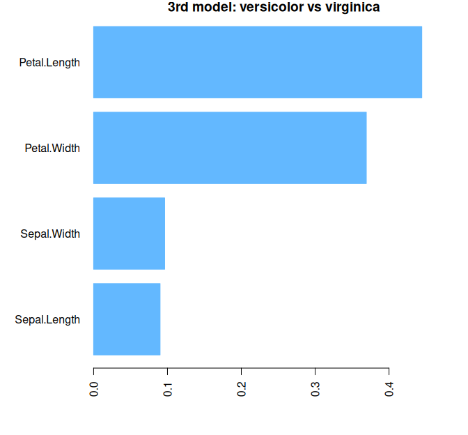

```
#> $first_features
#> [1] "Petal.Length" "Petal.Width"  "Sepal.Width"  "Sepal.Length"
#>
#> $cumsum
#> [1] 1
#>
#> $barplot
#>      [,1]
#> [1,]  0.7
#> [2,]  1.9
#> [3,]  3.1
#> [4,]  4.3
```

```r
plotImp(feat_imp3, leftmargin = 7, main="3rd model: versicolor vs virginica", color="steelblue1")
```

As we can see, the model considers the petals most discriminating that the sepals, and within the petals’ measures, the petal length.

If we return to the PCA, we could also check the weight of each variable in the first and second PCs (that is, the ones we displayed). To do so, it comes in handy the `kPCA_imp()` function. Again, this function requires the dataset that generated the `KL` matrix:

```r
loadings <- kPCA_imp(iris_std)
```

```
#> Do not use this function if the PCA was created with the RBF,
#>           Laplacian, Bray-Curtis, Jaccard/Ruzicka, or Kendall's tau kernels
```

```r
pcs <- loadings$loadings[1:2,]
pcs
```

```
#>     Sepal.Length Sepal.Width Petal.Length Petal.Width
#> PC1    0.5210659  -0.2693474   0.58041310  0.56485654
#> PC2    0.3774176   0.9232957   0.02449161  0.06694199
```

It seems that the first component is dominated by Petal Length and Petal Width but also by Sepal Length. The second component, that plays a role in discriminating *I. versicolor* and *I.virginica*, is dominated by Sepal Width. The PCA disagrees a bit with the SVM feature importances, but remember that in the latter we focused only on the “versicolor vs virginica” problem, while in the former we are looking at the ordination of the three classes. We may represent the contributions of the four features for the 1st PC, and to make things easier we will include the 2nd PC onto the barplot:

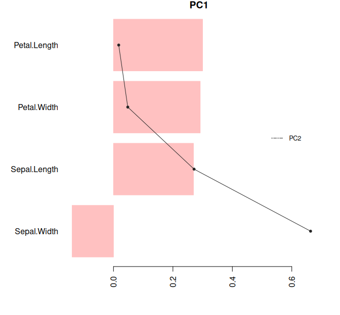

```
#> $first_features
#> [1] "Petal.Length" "Petal.Width"  "Sepal.Length" "Sepal.Width"
#>
#> $cumsum
#> [1] 1
#>
#> $barplot
#>      [,1]
#> [1,]  0.7
#> [2,]  1.9
#> [3,]  3.1
#> [4,]  4.3
```

```r
plotImp(pcs[1,], y=pcs[2,], ylegend="PC2",absolute=FALSE, main="PC1", leftmargin = 7,  color="rosybrown1")
```

We used `absolute=FALSE` because the contribution of each variable to the PC is relevant not only in magnitude, but also in sign. Pink bars represent PC1, while the black line represents PC2 (parameter `y`). As we only wanted to see the order and the relative magnitude, the X axis show the relative contribution (in the `plotImp()` function, `relative=TRUE` by default).

With `kerntools`, we can draw the contributions on the PCA plot as arrows. We only need the PCA plot (given by `kPCA()`) and the contributions (given by `kPCA_imp()`):

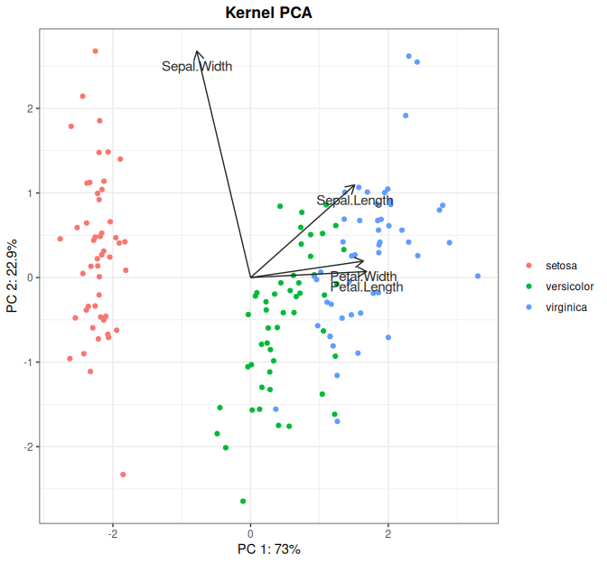

```r
kPCA_arrows(plot=kpca$plot,contributions=t(pcs),colour="grey15")
```

(Note that the arrows are scaled to match with the original PCA plot. They are somewhat orientative: their directions are correct, and longer arrows represent a greater contribution to a PC that shorter arrows; however, usually the arrows’ magnitudes do not coincide with the actual magnitudes that can be computed from `kPCA_imp()`).

And now, finally, we are going to check the performance in the test set (considering the 3 classes). To do so, we subset `KL` to have a suitable *test x training* matrix, input the matrix into our linear_model, and compare with the predicted species with the actual species:

```r
KL_test <- as.kernelMatrix(KL[test_idx,train_idx])
## Prediction (test data)
pred_class <- predict(linear_model,KL_test)
actual_class <- iris_species[test_idx]
pred_class
```

```
#>  [1] versicolor versicolor virginica  virginica  versicolor virginica
#>  [7] virginica  virginica  versicolor versicolor versicolor versicolor
#> [13] versicolor versicolor versicolor versicolor virginica  versicolor
#> [19] versicolor versicolor virginica  versicolor virginica  versicolor
#> [25] versicolor virginica  versicolor versicolor versicolor versicolor
#> Levels: setosa versicolor virginica
```

```r
actual_class
```

```
#>  [1] setosa     setosa     versicolor versicolor setosa     setosa
#>  [7] setosa     versicolor setosa     setosa     versicolor virginica
#> [13] virginica  virginica  virginica  virginica  setosa     versicolor
#> [19] setosa     setosa     setosa     setosa     versicolor setosa
#> [25] virginica  versicolor virginica  virginica  virginica  versicolor
#> Levels: setosa versicolor virginica
```

Mmmm… maybe we were a bit overconfident. It seems that the model has ignored *I. setosa* completely.

We can compute numerically how “good” (or wrong) our model is according to different performance measures implemented in `kerntools`. When dealing with classification, all of them need a contingency table that contrasts the actual and the predicted classes (also known as “confusion matrix”). The most simple measure is the accuracy: number of right predictions divided by the number of predictions (which is the test set size: in our case, 30).

```r
ct <- table(actual_class,pred_class) # Confusion matrix
ct
```

```
#>             pred_class
#> actual_class setosa versicolor virginica
#>   setosa          0          9         4
#>   versicolor      0          3         5
#>   virginica       0          9         0
```

```r
Acc(ct) ## Accuracy
```

```
#> [1] 0.1
```

```r
Acc_rnd(actual_class) ## Accuracy of the random model
```

```
#> [1] 0.3488889
```

As expected, our accuracy is overwhelmingly low. We can compare the result with the accuracy of the random model (according to the class distribution on the test): 0.35, which means that our model performs a lot worse than someone classifying at random.

We can explore other measures to infer what are the problems with our prediction model (for instance, if a species is systematically missclassified, etc.). For this example, we can compute these measures by class:

```r
Prec(ct,multi.class = "none") ## Precision or Positive Predictive Value
```

```
#>     setosa versicolor  virginica
#>  0.0000000  0.1428571  0.0000000
```

```r
Rec(ct,multi.class = "none") ## Recall or True Positive Rate
```

```
#>     setosa versicolor  virginica
#>      0.000      0.375      0.000
```

```r
Spe(ct,multi.class = "none") ## Specificity or True Negative Rate
```

```
#>     setosa versicolor  virginica
#>  1.0000000  1.0000000  0.5714286
```

```r
F1(ct,multi.class = "none") ## F1 (harmonic mean of Precision and Recall)
```

```
#>     setosa versicolor  virginica
#>  0.0000000  0.2068966  0.0000000
```

(In case we want the overall performance measure, we can compute the mean of the three classes, or type `multi.class="macro"`).

### A (slightly) more complicated example

In the previous section we picked naively the first model we could train, with not-so-great results. Here, we are going to complicate things a bit hoping that we will obtain a model that *works*.

(Note: of course, iris flower classification is a simple task. In fact, it can be achieved pretty decently with the linear kernel, as can be deduced from the previous PCA: a linear classifier is enough to discriminate the flowers using only the 1st and 2nd PCs. However, for the sake of the example, we will use a different kernel in the present section).

The radial basis function (RBF) kernel is something like the “gold standard” among kernels. Unlike the linear kernel (which is the most simple or “plain” kernel), it is nonlinear: in fact, the RBF kernel is a universal approximator. We can compute it doing:

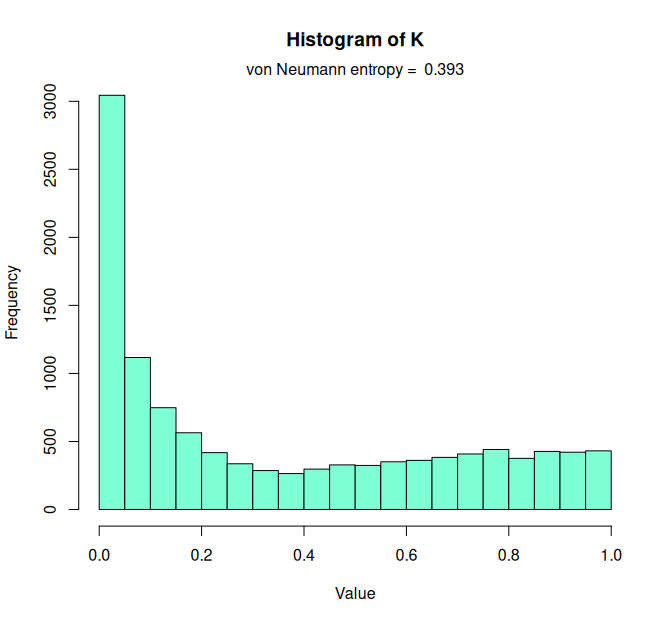

```r
Krbf <- RBF(iris_std,g=0.25)
histK(Krbf,col="aquamarine",vn = TRUE)
```

Kernel matrix values are typically between 0 and 1. The linear kernel required only our dataset, but `RBF()` has a (hyper)parameter called gamma (`g` for short). The value of this hyperparameter should be decided by us, which is an important decision, because it will affect the decision boundary of the kernel. Fortunately, some heuristics to estimate a good gamma exist. `kerntools` implement three of them, which are available in the function `estimate_gamma()`:

```r
estimate_gamma(iris_std)
```

```
#> $d_criterion
#> [1] 0.25
#>
#> $scale_criterion
#> [1] 0.2512584
#>
#> $quantiles_criterion
#>        90%        50%        10%
#> 0.05570343 0.16670322 1.73533468
```

In the previous histogram we visualized the RBF with the gamma given by the “d_criterion” (and almost the one given by the “scale criterion”). The third heuristic gives us a distribution of “good” gamma values. Now, for the sake of comparison, we will compute the RBF kernel using the median of the “quantiles_criterion”:

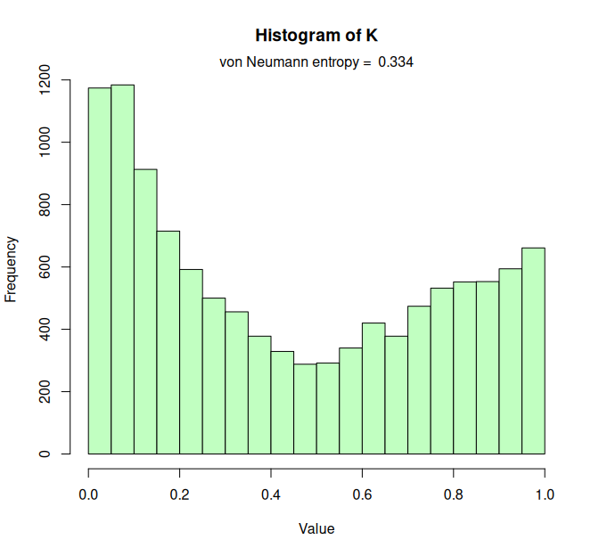

```r
Krbf2 <- RBF(iris_std,g=0.1667)
histK(Krbf2,col="darkseagreen1",vn=TRUE)
```

Not only the histogram changes: the von Neumann entropy changes as well. It important to remark that the RBF kernel is very sensitive to the gamma values. The higher entropy with respect to that of the linear kernel reflects that, here, we have a higher variability in the kernel matrix values. (That can be also be deduced comparing both histograms. Conversely, if we do `heatK(Krbf)`, we will observe more extreme values/colors than before). [This paper](https://pmc.ncbi.nlm.nih.gov/articles/PMC9858626/) recommends an entropy between 0.3-0.5, so maybe this will be reflected on the SVM model’s performance?

Now, we can also do a kernel PCA. Our previous kernel PCA used a linear kernel so, in reality, it was identical to a “normal” PCA. This time however we are using a different kernel and now we can actually say that this is a kernel PCA. The main difference is that the projection of samples is *not* going to be linear. Sometimes, this creates strange patterns that are difficult to interpret.

As later we are going to train a SVM model, it may occur to us that it would be great to do a PCA only with the training samples, so we can compare the prediction model with the PCA side by side. To do so, we will use the same training indices than in the previous section. Even better: what if we compute a (kernel) PCA with the training samples, and then project the test samples over them?

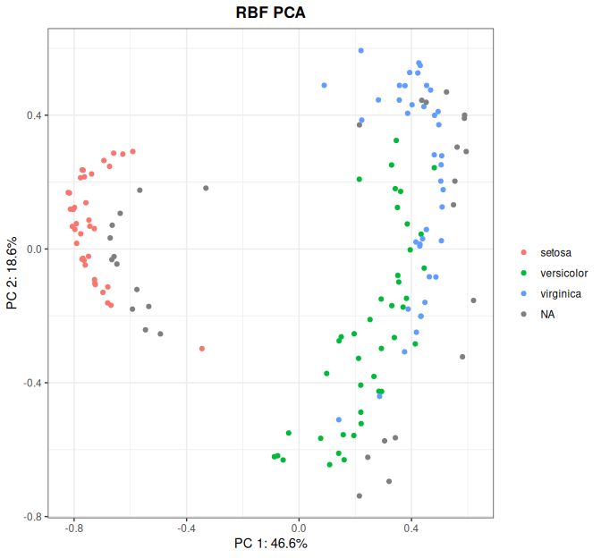

```r
Krbf_train <- Krbf2[train_idx,train_idx]
Krbf_test <- Krbf2[test_idx,train_idx]
rbf_kpca <- kPCA(K=Krbf_train, Ktest=Krbf_test, plot = 1:2, y = iris_species[train_idx], title = "RBF PCA")
rbf_kpca$plot
```

(Note: remember that, in a real-world problem, the standardization of the dataset should have been done with the center and std deviation of the training set.)

Said and done! However, now the patterns on this kernel PCA are a bit… radial. Still, *I. setosa* is again on one side, and *I. versicolor* and *I. virginica* on the other. The red, green and blue samples are the training samples, where the grey samples correspond to the test samples we projected *a posteriori* (any other color can be specified in the `kPCA` parameter `na_col`).

What now? As we have generated more than one kernel matrix from the same data (thanks to the linear and the RBF kernels), we may compare these matrices. To do so, we can use a `kerntools` function called `simK`:

```r
simK(list(linear=KL,rbf_0.166=Krbf, rbf_0.25=Krbf2))
```

```
#> Remember that Klist should contain only kernel matrices (i.e. squared, symmetric and PSD).
#>   This function does NOT verify the symmetry and PSD criteria.
#>              linear rbf_0.166  rbf_0.25
#> linear    1.0000000 0.5208955 0.4803192
#> rbf_0.166 0.5208955 1.0000000 0.9898203
#> rbf_0.25  0.4803192 0.9898203 1.0000000
```

`simK` will first remind us that a matrix should have several mathematical properties to be a kernel matrix. When we work with kernel matrices generated by `kerntools` (that is: `Linear()`, `RBF()`, etc.) everything will be alright. However, you can come to `kerntools` with your precomputed kernel matrices (as long as they have class “matrix”, “array”). `kerntools` implicitly trusts the user knows what he/she is doing, so remember using proper kernel matrices.

`simK` returns a score between 0 and 1: 1 is complete similarity, and 0 is complete dissimilarity. We can see that the two RBF matrices are very similar, while the linear kernel matrix is around a 50% similar to the RBF matrices.

We could also compare the two PCAs. An option to do so is computing the RV coefficient (Co-Inertia Analysis). However, the RV coefficient between `rbf_kpca` and `kpca` should give the same result than `simK(list(KL,Krbf))`. It should be noted that this equivalence only holds if the dataset is centered beforehand, as PCAs usually are computed using centered data (for that reason we have `kPCA(..., center=TRUE)` by default). If a kernel matrix was obtained from a non-centered data, it can be centered afterwards with `centerK()` (more of this in later sections).

Another way to compare two PCAs is called the Procrustes Analysis. This analysis compares the correlation between two projections after “removing” the translation, scale and rotation effects. Although is not properly a kernel method, `kerntools` can do a basic Procrustes Analysis. In our data, we have a moderate Procrustes correlation: 0.68 (the correlation coefficient is bounded between 0 and 1).

```r
rbf_kpca <- kPCA(K=Krbf)
proc <- Procrustes(kpca$projection,rbf_kpca)
proc$pro.cor # Procrustes correlation
```

```
#> [1] 0.6862007
```

(This is a moment as good as any other to show that `kPCA()` can return the kernel PCA projection without displaying any plot. In that case, all graphical parameters like colors, labels, etc. are ignored.)

With all of these, we will train a brand new (and hopefully better) model. We will re-use the same training and test samples:

```r
####### Model (training data)
model <- kernlab::ksvm(x=Krbf_train, y=iris_species[train_idx], kernel="matrix", C=10)
model
```

```
#> Support Vector Machine object of class "ksvm"
#>
#> SV type: C-svc  (classification)
#>  parameter : cost C = 10
#>
#> [1] " Kernel matrix used as input."
#>
#> Number of Support Vectors : 30
#>
#> Objective Function Value : -4.1707 -2.7089 -92.348
#> Training error : 0.008333
```

A very low training error, but now we are wiser. What about the performance in test?

```r
Krbf_test <- as.kernelMatrix(Krbf_test)
####### Prediction (test data)
pred_class <- predict(model,Krbf_test)
actual_class <- iris_species[test_idx]
ct <- table(actual_class,pred_class) # Confusion matrix
Acc(ct) ## Accuracy
```

```
#> [1] 0.5
```

Wow, that seems a lot better! However, before we get excited, we must remember that this is a point estimation of accuracy, that comes from a specific test set (the 30 samples we chose randomly in the previous section). Another test set surely will deliver a different accuracy. What if we tried to compute a confidence interval (CI) to have an idea of how other test sets will behave?

`kerntools` provides two ways to obtain a CI: the Normal Approximation, and bootstrapping. Normal approximation is quicker, while bootstrapping is usually considered to be safer (more details: [here](https://sebastianraschka.com/blog/2022/confidence-intervals-for-ml.html)):

```r
 ## Accuracy CI (95%)
Normal_CI(value = 0.5,ntest = 30) ## Accuracy CI (95%)
```

```
#> [1] 0.3210806 0.6789194
```

```r
Boots_CI(target = actual_class, pred = pred_class, nboots = 2000,index = "acc")
```

```
#>                2.5%     97.5%
#> 0.5016667 0.3333333 0.7000000
```

Before call it a day, we are going to compute again the other performance measures. This time, we will not compute them class by class, but on average (the “macro” approach):

```r
Prec(ct) ## Precision or Positive Predictive Value
```

[output not shown]

```r
Rec(ct) ## Recall or True Positive Rate
```

```
#> [1] 0.4807692
```

```r
Spe(ct) ## Specificity or True Negative Rate
```

```
#> [1] 0.8085477
```

```r
F1(ct) ## F1 (harmonic mean of Precision and Recall)
```

```
#> [1] 0.4484848
```

If we desire to do, we can compute a CI for these values: for instance, to bootstrap the macro-F1 value, we could simply type `index = "f1"` in the `Boots_CI()` function. In any case, we should congratulate ourselves because the performance is clearly higher than last time. Training *seriously* a machine learning model involves fine hyperparameter tuning (remember that C in `ksvm()`?) that we have almost completely skipped. That is: we should use a strategy like, say, grid search, and compare the performance measures of each hyperparameter combination via cross validation, which is far beyond the purposes of this vignette (and `kerntools`).

Finally, a warning about computing feature importances in SVM and/or feature contribution to PCs in PCA. In a few words: don’t do that when using the RBF kernel. More precisely: of all kernel functions implemented here, do not ever try to recover the feature contributions for `RBF()`, `Laplace()`, `Jaccard()`, `Ruzicka()`, `BrayCurtis()` and `Kendall()` unless you know *very* well what you are doing. If you type something like:

```r
####### RBF versicolor vs virginica model:
sv_index <- kernlab::alphaindex(model)[[3]]
sv_coef <- kernlab::coef(model)[[3]]
svm_imp(X=iris_std[train_idx,],svindx=sv_index,coeff=sv_coef)
```

```
#> Do not use this function if the SVM model was created with the RBF,
#>           Laplacian, Bray-Curtis, Jaccard/Ruzicka, or Kendall's tau kernels
#> Sepal.Length  Sepal.Width Petal.Length  Petal.Width
#>    0.8931422    0.7828191   12.3522663   10.0792776
```

something will be computed, but the result **is wrong**. Do not ignore the warning raised here. This is not right because, ultimately, all kernels behave like the linear kernel: they compute the inner product of some features. But what features? That is the question. Under the hood, all kernels “send” the original features (the feature that live in the *input space*) to other space (usually higher-dimensional) called the *feature space*, and they compute the inner product there. The kernel conflates these two steps into one, which usually simplifies a lot the calculations and saves a lot of memory space: this is called the “kernel trick”. But to compute analytically the feature contributions we need to go that feature space. To make things worse, the feature space that the kernel implicitly is using depends on things like the dimensionality of input data, the kind of kernel, the specific value of its hyperparameters, etc. Going to this feature space is only trivial for the linear kernel: only then input space = feature space. Instead, for the RBF kernel, this feature space is infinite dimensional. Some techniques to estimate it exist (see for instance: [Explicit Approximations of the Gaussian Kernel](https://arxiv.org/abs/1109.4603)), but they are not yet implemented in `kerntools` (and maybe they never are).

## Non-standard data, exotic normalizations, and more about feature spaces

The natural workflow of this package has been shown (twice) in previous sections. For that reason, the remainder of this vignette will deal with more obscure (and interesting) matters concerning kernels for “non-standard” kinds of data. Also, we will delve deeper in the feature space and normalization effects.

### Non-standard data

Until now, we have worked with kernels for real vectors. That is, we had a dataset that consisted of several features (four in our case: the sepal and petal length and width) measured in a set of individuals (the 150 iris flowers). Another way of looking at it is considering that we had 150 vectors of length 4 (incidentally, this is the way kernel functions look at data). These were real vectors (or, at least, they were after we standardized them). Unknowingly, we have also have worked with kernels for real matrices: we compared three kernel matrices with `simK()` and the result was… another kernel matrix. In fact, `simK()` is simply a wrapper of `Frobenius()`. In the Frobenius kernel, the input of the function (the “objects” they work with) are not vectors, but numeric *matrices*.

Most machine learning methods work primarily with real vectors or, in some cases, matrices. In the case of the kernel methods, they can work with virtually any kind of data we can think of. This is because what the kernel method (SVM, kernel PCA, etc) sees is the kernel matrix, not the original objects. So, as long as we can create a valid (i.e. symmetric and PSD) kernel function for our objects, everything will turn just well. The list of kernel functions is endless. Right now, `kerntools` can deal effortlessly with the following kinds of data:

- Real vectors: Linear, RBF, Laplacian kernels
- Real matrices: Frobenius kernel
- Counts or Frequencies (non-negative numbers): Bray-Curtis, Ruzicka (quantitative Jaccard) kernels
- Categorical data: Overlap / Dirac kernel
- Sets: Intersect, Jaccard kernels
- Ordinal data / rankings: Kendall’s tau kernel
- Strings / Text: Spectrum kernel

All of them are commonly used in different fields. For instace, categorical data is as widespread as numeric data (or more), text mining and content analysis is right now a very lively research field, and the Bray-Curtis and Ruzicka kernels are closely related to famous beta-diversity indices used in ecological studies.

We will illustrate how `kerntools` works with categorical variables. (For the rest of kernel functions, please read in detail their specific documentation page). `kerntools` includes a categorical dataset called `showdata`:

```r
summary(showdata)
```

```
#>    Favorite.color             Favorite.actress        Favorite.actor
#>  blue     :20     Sophie Turner       :22      Peter Dinklage:20
#>  red      :20     Emilia Clarke       :19      Kit Harington :17
#>  black    :14     Anya Chalotra       :12      Henry Cavill  :15
#>  purple   :12     Freya Allan         :10      Lee Jung-jae  :15
#>  green    : 8     Helena Bonham Carter: 8      Hyun Bin      : 8
#>  lightblue: 8     Lorraine Ashbourne  : 7      Josh O'Connor : 7
#>  (Other)  :18     (Other)             :22      (Other)       :18
#>           Favorite.show Liked.new.show
#>  Game of Thrones :22    No :48
#>  The witcher     :17    Yes:52
#>  Bridgerton      :14
#>  Squid game      :11
#>  The crown       :11
#>  La casa de papel: 8
#>  (Other)         :17
```

```r
dummy_showdata <- dummy_data(showdata)
dummy_showdata[1:5,1:3]
```

```
#>   Favorite.color_black Favorite.color_blue Favorite.color_green
#> 1                    0                   0                    0
#> 2                    1                   0                    0
#> 3                    0                   0                    0
#> 4                    0                   1                    0
#> 5                    0                   0                    0
```

(sometimes, like in Linear Models, the design matrix contains *L-1* dummy variables. This kind of recoding can done with `model.matrix()`)

The approach using kernels is a bit different. Here we will work with the original dataset. The kernel will make the pairwise comparisons of the *N = 100* samples and, for every pair of samples, it will ask: it this class equal in the two samples, or is it different? For example: “Favorite.color” is “red” in sample 1, “black” in sample 2, and “red” again in sample 3. The comparison of this categorical feature between samples 1-2 will return FALSE, while comparing samples 1-3 will return TRUE.

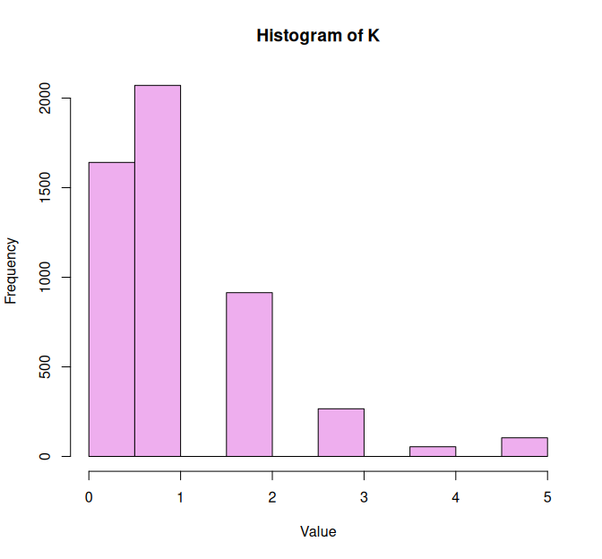

```r
KD <- Dirac(showdata, comp="sum")
histK(KD, col ="plum2")
```

As we have not a single categorical variable but *D=5*, we should combine the results of this comparison for the *D* variables. That’s why we stated `comp="sum"`: to make the kernel sum the FALSES and TRUES of pairwise comparing “Favorite.color”, “Favorite.actress”, “Favorite.actor”, “Favorite.show” and “Liked.new.show” (we have also the option to average them, or compute a weighting average, if we consider that some features are more important than others). The histogram of `KD` shows there are a few identical samples, a lot of samples that are completely different, and most of samples only are equivalent in one of the 5 features.

Now we have our kernel matrix! Now we can do with it whatever we want, included training a prediction model or computing a kernel PCA. Yes, exactly: although PCA is a technique that was originally created for real numeric data, another advantage yet of kernels is that we can do PCA of everything. For simplicity, here we will not train the prediction model (but you are free to follow the steps shown in the previous section), and will only show the kernel PCA As `showdata` contains the result of a (fictional) survey with the idea to predict if people preferences could predict it they liked or not a new show, this time, we are computing the kernel for features 1:4, so we can color the kernel PCA with feature 5 (“Did you like the show?”). Furthermore, for a change, we will also draw ellipses around the centroids of the “Yes” group and the “No” group:

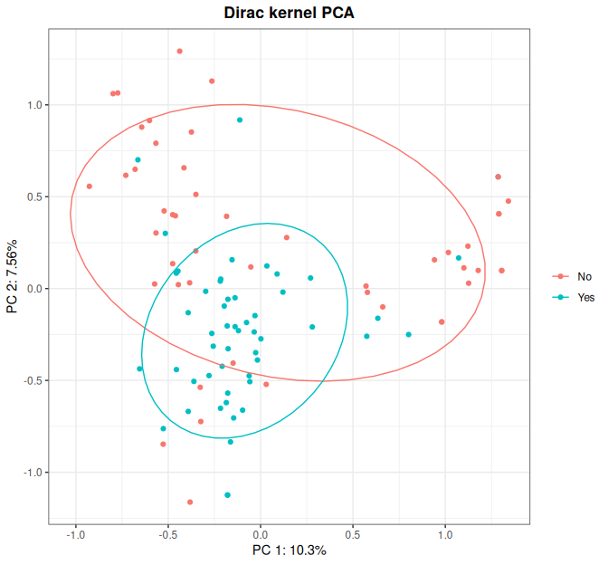

```r
KD <- Dirac(showdata[,1:4], comp="sum",feat_space=TRUE)
dirac_kpca <- kPCA(KD$K,plot=1:2,y=factor(showdata$Liked.new.show),ellipse=0.66,title="Dirac kernel PCA")
dirac_kpca$plot
```

It seems that the group that liked the show forms a tight cluster, while people that do not liked it is scattered along the PC1. Now, we can study the contributions of each class and see if our intuitions are confirmed:

```r
pcs <- kPCA_imp(KD$feat_space)
```

```
#> Do not use this function if the PCA was created with the RBF,
#>           Laplacian, Bray-Curtis, Jaccard/Ruzicka, or Kendall's tau kernels
```

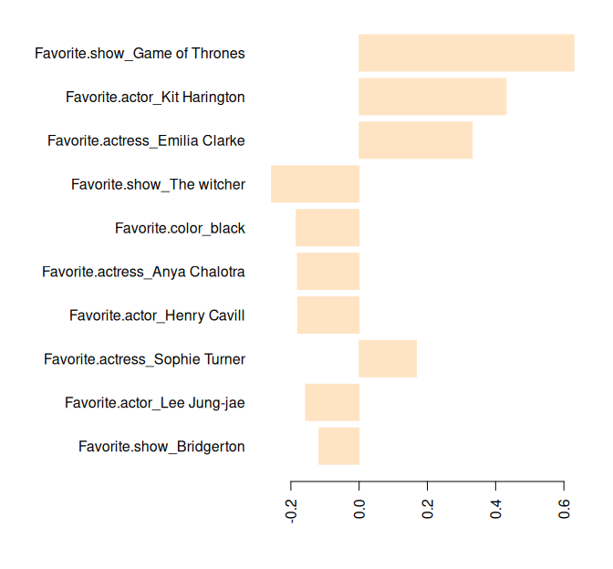

```r
pc1 <- plotImp(pcs$loadings[1,],leftmargin=15,nfeat=10,absolute = FALSE,  relative = FALSE,col ="bisque")
```

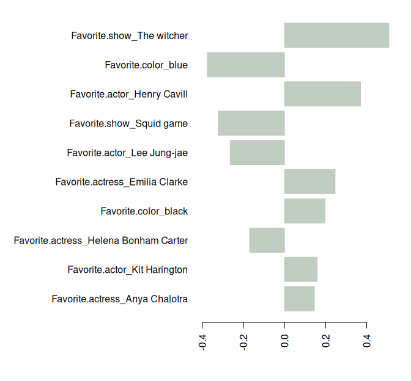

```r
pc2 <- plotImp(pcs$loadings[2,],leftmargin=17,nfeat=10,absolute = FALSE, relative = FALSE, col="honeydew3")
```

(These plots show only the top 10 features.)

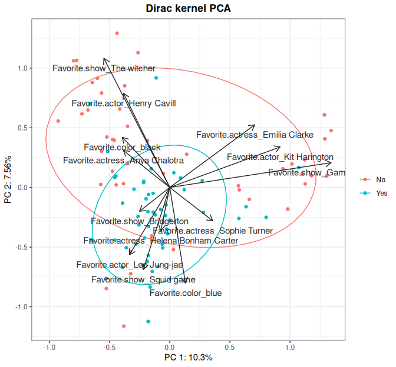

```r
features <- union(pc1$first_features,pc2$first_features)
kPCA_arrows(plot=dirac_kpca$plot,contributions=t(pcs$loadings[1:2,features]),colour="grey15")
```

In summary, it would seem that a relevant fraction of these dataset is divided between the Game of Thrones and The Witcher fans, but both of them have one thing in common: they very clearly did **not** like the new show.

In previous code, we computed not only the Dirac kernel matrix, but also its feature space (`feat_space=TRUE`). Conveniently, the natural feature space where the Dirac kernel works is the same generated by one-hot-encoding. That is what allowed us to compute the contributions of each class (or dummy variable) to the PC1 and 2.

Finally, the importance of the dummy variables may be aggregated, so we can recover the overall importance of the original features. For instance, consider the following SVM model for the `showdata`:

```r
dirac_model <- kernlab::ksvm(x=KD$K, y= factor(showdata$Liked.new.show), kernel="matrix",C=0.1)
```

(For simplicity, in this particular model we have allocated all data to the training set). As seen in A simple example, feature importances are obtained like this:

```r
sv_index <- unlist(kernlab::alphaindex(dirac_model)) # Vector with the SV indices
sv_coef <- unlist(kernlab::coef(dirac_model)) # Vector with the SV coefficients
feat_imp <- svm_imp(X=KD$feat_space,svindx=sv_index,coeff=sv_coef,result="raw")
```

```
#> Do not use this function if the SVM model was created with the RBF,
#>           Laplacian, Bray-Curtis, Jaccard/Ruzicka, or Kendall's tau kernels
```

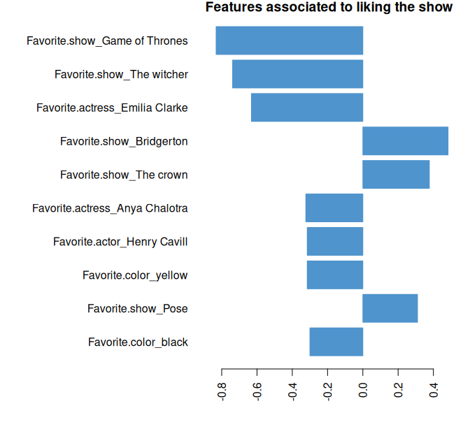

[output not shown]

```r
plotImp(feat_imp,leftmargin=15,nfeat=10,absolute = FALSE,  relative = FALSE,
        col ="steelblue3",main="Features associated to liking the show")
```

Again, we can observe that having a special preference for Game of Thrones/The Witcher seems related to *not* liking the new show. Now, we can aggregate the 41 dummy variables into the 4 original categorical variables (“Favorite.color”, “Favorite.actress”, “Favorite.actor” and “Favorite.show”) so we can rank them. To do so, we can use the `kerntools` function `aggregate_imp()`:

```r
abs_feat_imp <- as.matrix(abs(feat_imp)) ## We take the absolute importances
aggregate_imp(X=abs_feat_imp,lev=colnames(showdata)[-5],samples="cols")
```

```
#>      Favorite.color Favorite.actress Favorite.actor Favorite.show
#> [1,]       1.476732          2.11009       1.276732      3.140257
```

Our grouping criteria (`lev`) are the original variables’ names, while `samples="cols"` means that the features we are interested in are in the rows of the `abs_feat_imp` matrix. According to the SVM model, the most relevant question in the survey is “Favorite.show”, as it has the highest weight in the respondents’ answer (“I like the new show”/“I don’t like the new show”).

### Normalization techniques

`kerntools` provides functions for some normalization techniques. Several are specific of kernel matrices, other are for data matrices in general, and some of them are for both.

First we will see the normalization of data matrices or data.frames. One of the most used techniques is standardization, which we saw in previous sections. This is already implemented in R base via `scale(X,center=TRUE,scale=TRUE)`, which allows standardizing (by column) or only centering or scaling (by column). `kerntools` has the `minmax()` normalization, which normalizes the dataset between 0 and 1. The `centerX()` function centers a squared dataset by row or column (yes, only squared datasets: to center by row a *NxD* dataset, you may use `scale(t(X),center=T,scale=F)`). Another useful function is `TSS()`, which operates too by row or column, and transforms absolute frequencies to relative ones, so the row (or column) sums to 1. In this vein, `cosnormX()` normalizes by the L2 norm by row (or column): that is, the norm of each row (or column) sums to 1. These functions usually default to row-normalization, as this is the way kernel functions look at data (`minmax()` is an exception). Finally, normalization for the Frobenius norm is available for data matrices (and also kernel matrices) via `frobNorm()`.

Apart from the Frobenius normalization, `kerntools` has two more normalization functions for kernel matrices: `cosNorm()` and `centerK()`. The first one applies the cosine normalization to a kernel matrix, so its maximum value is 1 (sometimes, this also bound the minimum value around 0). This operation is related to `cosnormX()`. In fact, when working with the linear kernel (but only in that case!), these two operations are equivalent:

```r
KL1 <- Linear(cosnormX(iris[,1:4])) # important: by row
KL2 <- cosNorm(Linear(iris[,1:4])) # a third valid option is: Linear(iris[,1:4], cos.norm=TRUE)
simK(list(KL1=KL1,KL2=KL2))
```

```
#> Remember that Klist should contain only kernel matrices (i.e. squared, symmetric and PSD).
#>   This function does NOT verify the symmetry and PSD criteria.
#>     KL1 KL2
#> KL1   1   1
#> KL2   1   1
```

The second function is `centerK()` (needless to say, this function is somewhat related to `centerX()`). Again, centering the dataset by column and then computing the linear kernel, or computing the linear kernel and then centering it with `centerK()` is equivalent. Then, why have two duplicated ways for doing the same? Well, apart of speed (which expression is faster depends on the dataset dimension, that is, if it has more rows or columns), these expressions are only equivalent when using the linear kernel. When using another kernel, `cosnormX()` and `centerK()` normalize or center the kernel matrix… according to features in feature space. Not in the input space. For this reason, this:

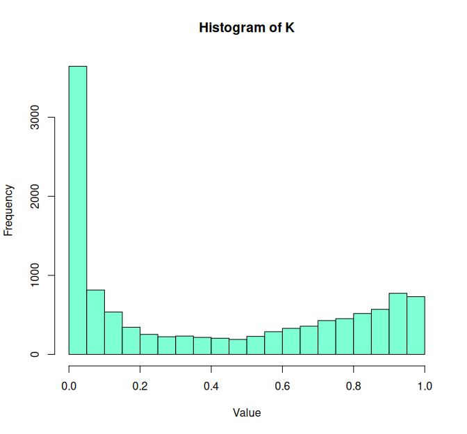

```r
center_iris <- scale(iris[,1:4],scale=FALSE,center=TRUE)
histK(RBF(center_iris,g=0.25),col="aquamarine")
```

and this:

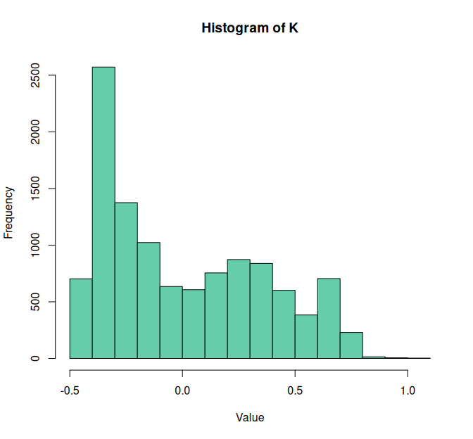

```r
histK(centerK(RBF(iris[,1:4],g=0.25)),col="aquamarine3")
```

don’t look alike in the slightest.

(Incidentally, it should be noted that RBF is translation-invariant with respect to variables in input space. That is: standardization is useful for this kernel, but simply centering is not. `RBF(iris[,1:4],g=0.25)` and using `center_iris` is the same.)

In summary: if we want that the two are equivalent (like in the linear kernel), we should computing the L2 norm or the centering using the feature space, *not* the input space. This cannot be done for the `RBF()` function, although it is possible for the kernels stated in the previous subsection.

Up to this moment we have explained normalization for real data. But what about the other kinds of data? Well, `kerntools` favors the approach the other kinds of data are best dealt with kernel functions. Also remember that some of the `kerntools` kernel functions of the previous subsection will also return the feature space on demand. Still, `kerntools` offers a basic one-hot-encoding for categorical data. That is provided by `dummy_data()`, which converts a categorical dataset to a one-hot-encoded one. (This is the feature space where the Dirac kernel works). This function requires that the user specifies the number of levels per factor, but this can be easily done with another function: `dummy_var()`.

### Fusing data. A word about *a priori* and *a posteriori* feature importances.

One advantage of using kernel matrices instead of original datasets is that kernel matrices can be combined very easily. For instance, imagine that we have two (or more) sources of data for the same individuals. In our example, dataset1 is numeric and has dimension *NxD<sub>1</sub>*, while the dataset2 has dimension *NxD<sub>2</sub>* and contains other kind of data (for example categorical). You cannot sum or multiply these two datasets; however, you *can* sum or multiply their kernel matrices K1 and K2.

Let’s see a very simple illustration with the dataset `mtcars`.

```r
dim(mtcars)
```

```
#> [1] 32 11
```

```r
head(mtcars)
```

```
#>                    mpg cyl disp  hp drat    wt  qsec vs am gear carb
#> Mazda RX4         21.0   6  160 110 3.90 2.620 16.46  0  1    4    4
#> Mazda RX4 Wag     21.0   6  160 110 3.90 2.875 17.02  0  1    4    4
#> Datsun 710        22.8   4  108  93 3.85 2.320 18.61  1  1    4    1
#> Hornet 4 Drive    21.4   6  258 110 3.08 3.215 19.44  1  0    3    1
#> Hornet Sportabout 18.7   8  360 175 3.15 3.440 17.02  0  0    3    2
#> Valiant           18.1   6  225 105 2.76 3.460 20.22  1  0    3    1
```

`mtcars` has 11 features: 9 are numeric while 2 can be though as categorical: vs (engine, which can be V-shaped or straight), and am (transmission: automatic or manual). We can split mtcars in two parts: a data.frame with the numeric features and a data.frame with the categorical ones:

```r
cat_feat_idx <- 8:9
MTCARS <- list(num=mtcars[,-cat_feat_idx], cat=mtcars[,cat_feat_idx])
```

Now we prepare a kernel matrix for each data.frame. For the dataset1 we use the linear kernel and for the dataset2 we use the Dirac kernel:

```r
K <- array(dim=c(32,32,2))
K[,,1] <- Linear(MTCARS[[1]]) ## Kernel for numeric data
K[,,2] <- Dirac(MTCARS[[2]]) ## Kernel for categorical data
```

We can create a “consensus” kernel from K1 and K2 using a `kerntools` function:

```r
Kcons <- MKC(K)
```

It should be noted that, here, `K1` has the same weight than `K2` when computing the final kernel, although `K1` has 9 variables and `K2` has only 2. If we want to weight equally each one of the 11 variables in the final kernel, we can do:

```r
coeff <- sapply(MTCARS,ncol)
coeff #  K1 will weight 9/11 and K2 2/11.
```

```
#> num cat
#>   9   2
```

```r
Kcons_var <- MKC(K,coeff=coeff)
```

Now, maybe we fancy comparing `K1` and `K2` to our consensus kernel matrices:

```r
simK(list(Kcons=Kcons,K1=K[,,1],K2=K[,,2]))
```

```
#> Remember that Klist should contain only kernel matrices (i.e. squared, symmetric and PSD).
#>   This function does NOT verify the symmetry and PSD criteria.
#>           Kcons        K1        K2
#> Kcons 1.0000000 1.0000000 0.7871094
#> K1    1.0000000 1.0000000 0.7871069
#> K2    0.7871094 0.7871069 1.0000000
```

```r
simK(list(Kcons_var=Kcons_var,K1=K[,,1],K2=K[,,2]))
```

```
#> Remember that Klist should contain only kernel matrices (i.e. squared, symmetric and PSD).
#>   This function does NOT verify the symmetry and PSD criteria.
#>           Kcons_var        K1        K2
#> Kcons_var 1.0000000 1.0000000 0.7871074
#> K1        1.0000000 1.0000000 0.7871069
#> K2        0.7871074 0.7871069 1.0000000
```

Mmm… something strange is happening here. Shouldn’t `K2` be more similar to the consensus matrix in the former case than in the latter? This phenomenon is caused because we did not normalize dataset1 nor `K1.` And then, we averaged `K1` and `K2`, without taking into account that `K1` has very large values in comparison to `K2`:

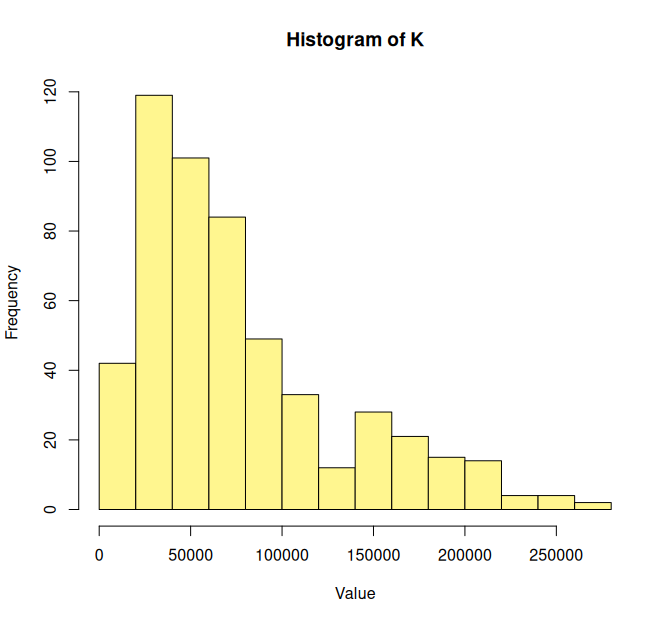

```r
histK(K[,,1], col="khaki1")
```

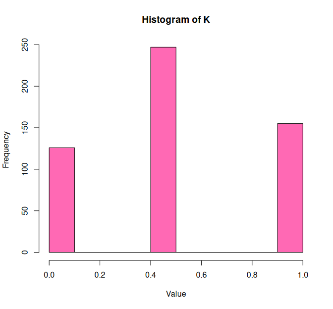

```r
histK(K[,,2], col="hotpink")
```

That is: we though that `K2` was overrepresented in the consensus kernel… but actually it was the other way around.

In previous sections we have seen the feature importance given by SVM models. That can be considered like some kind of *a posteriori* feature importance. However, we should be cautious regarding the implicit weights that we give to the features *before* training the model. We can think about this like some kind of *a priori* (my apologies to bayesian statisticians for this nomenclature!) feature importance. It is important to have this implicit weighting in mind because the SVM (or whatever other method we use) is *not* seeing the original data, but our kernel matrices. In fact, this “scale” problem arises in other (non-kernel) methods: for these reason we are advised to normalize or standardize numeric datasets.

Now, this time *for real*, we try to weight equally all our 11 features:

```r
K[,,1] <- Linear(minmax(MTCARS[[1]])) ## Kernel for numeric data
K[,,2] <- Dirac(MTCARS[[2]],comp="sum") ## Kernel for categorical data
Kcons <- MKC(K)
Kcons_var <- MKC(K,coeff=coeff)
simK(list(Kcons=Kcons,K1=K[,,1],K2=K[,,2]))
```

```
#> Remember that Klist should contain only kernel matrices (i.e. squared, symmetric and PSD).
#>   This function does NOT verify the symmetry and PSD criteria.
#>           Kcons        K1        K2
#> Kcons 1.0000000 0.9791777 0.9663366
#> K1    0.9791777 1.0000000 0.8939859
#> K2    0.9663366 0.8939859 1.0000000
```

```r
simK(list(Kcons=Kcons_var,K1=K[,,1],K2=K[,,2]))
```

```
#> Remember that Klist should contain only kernel matrices (i.e. squared, symmetric and PSD).
#>   This function does NOT verify the symmetry and PSD criteria.
#>           Kcons        K1        K2
#> Kcons 1.0000000 0.9977012 0.9222967
#> K1    0.9977012 1.0000000 0.8939859
#> K2    0.9222967 0.8939859 1.0000000
```

The details maybe sound a bit too specific, but the min-max normalization bounds the numeric data between 0 and 1. The range [0,1] is the same than the one-hot-encoding for categorical variables (the feature space related to the Dirac kernel). In addition, we chose `comp=sum` because the linear kernel also “sums” each one of the features. Now, both `K1` and `K2` are almost equally similar to the consensus in the first case, and `K2` is less similar in the second case. `K1` and `K2` have still a high similarity, but this is probably caused because features in `mtcars` are correlated.